# Bivariate Relationships Assignment

### Step 1: Determine what variables for your two main constructs you want to graph based on your research topic.

You will need a mixture of categorical and quantitative variables for this assignment.

- One association with a categorical explanatory and categorical response variable. (C ~ C)
- One association with a categorical explanatory and quantitative response variable. (Q ~ C)
- One association with a quantitative explanatory and binary categorical response variable. (B ~ Q)
- One association with a quantitative explanatory and quantitative response variable. (Q ~ Q)

If you do not have 1 or more of the combinations above you will do one of the specific types mentioned more than once.

*Recall the following definitions:*

- Explanatory variable: independent variable, covariate, goes along the x axis
- Response variable: dependent variable, outcome, goes along the y axis.
- Model definition: y ~ x
  - C: categorical
  - B: binary categorical
  - Q: quantitative numeric / continuous

### Step 2: Recode variables as needed.

If your response variable is categorical with many levels, you may want to collapse it down to fewer levels. The example code below uses the `diamonds` data set from the `ggplot2` package. Here I combine levels `D` and `E` into a single category `DE`, `F` and `G` are combined into `FG`, and the remaining three `H`, `I`, and `J` are combined into a `HIJ` category.

The code `car::recode()` means I am using the `recode()` function that is located in the `car` library. This is a shortcut to using a function inside a package without having to load that package.

```r
library(ggplot2)
table(diamonds$color)
```

```
##
##     D     E     F     G     H     I     J
##  6775  9797  9542 11292  8304  5422  2808
```

```r
diamonds$col_cat <- car::recode(diamonds$color, "'D' = 'DE'; 'E' = 'DE';
                                     'F' = 'FG'; 'G' = 'FG';
                                     'H' = 'HIJ'; 'I' = 'HIJ'; 'J' = 'HIJ'")
table(diamonds$col_cat, diamonds$color)
```

```
##
##           D     E     F     G     H     I     J
##   DE   6775  9797     0     0     0     0     0
##   FG      0     0  9542 11292     0     0     0
##   HIJ     0     0     0     0  8304  5422  2808
```

If I simply need a binary indicator, the `factor()` function is more easily used. Recall that the first logical statement `diamonds$cut=="Ideal"` will result in a vector of `TRUE` which is treated as a 1, and `FALSE` which is treated as a 0. Then the `labels=` argument applies appropriate lables in ascending numerical order: 0 first, then 1.

```r
table(diamonds$cut)
```

```
##
##      Fair      Good Very Good   Premium     Ideal
##      1610      4906     12082     13791     21551
```

```r
diamonds$ideal <- factor(diamonds$cut=="Ideal", labels=c("Less than Ideal", "Ideal"))
table(diamonds$ideal, diamonds$cut)
```

```
##
##                    Fair  Good Very Good Premium Ideal
##   Less than Ideal  1610  4906     12082   13791     0
##   Ideal               0     0         0       0 21551
```

### Step 3: Create appropriate graphics

- Create one bivariate graph for each of the four combinations listed in step 1.
- You can do any combination of the 4 types of bivariate graphs for a total of 4.
  - Do as many different combinations as you can. Not just 4 graphics on one combination (i.e. C~C)
- For each graph, you need to explain what association (relationship) you are graphing.
  - Then use the graph to explain the relationship or trends you see in the data.
  - Place discussion of relationship below the graph it corresponds with.
  - Use specific features of the graphic in your text explanation.
  - Calculate and use summary statistics and also use those in your text explanation.

### Step 4: Submit to Blackboard by the deadline

- Knit to PDF or HTML. Don’t hide your code.
- This is a peer review assignment.

# Example

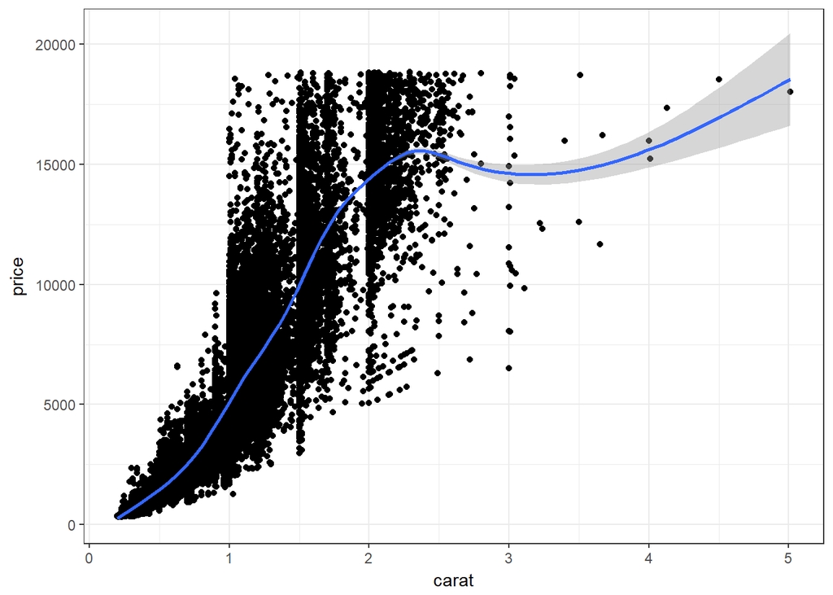

```r
ggplot(diamonds, aes(x=carat, y=price)) + geom_point() + theme_bw() + geom_smooth()
```

```r
cor(diamonds$carat, diamonds$price)
```

```
## [1] 0.9215913
```